# Capstone Project Proposal

### Marissa Cruse - Master of Urban Spatial Analytics

## Introduction

The goal of this project is to investigate whether spatial clusters emerge in music streaming patterns based on the geographic origin of artists. By testing for spatial autocorrelation, we aim to identify potential clusters within the music industry's streaming data. This exploration offers an opportunity to observe how music shapes cities and communities. Furthermore, the envisioned web application, serving as the foundation of this exploration, aims to enhance users' understanding of the cultural significance embedded within music.

## Background Literature

### The Rap Quotes Coast to Coast - Jay Shells

The Rap Quotes Coast to Coast is a visual catalog of site-specific rap lyrics in Los Angeles, New York, Philadelphia, Houston, Atlanta, and more. In this exploration, Jason Shelowitz places custom street signs that feature rap lyrics that reference the respective location. This spatial analysis of hip-hop and rap lyrics sheds light on how rappers and hip-hop artists are influenced and inspired by their built environment. Understanding the relationship between music and geography is fundamental to exploring the existence of clustering in the music industry.

### The Secret History of Drill - Vice

When utilizing this tool, users should feel compelled to explore the fascinating histories behind the maps showcasing the origins of their favorite artists. How music is adapted and popularized in certain regions helps us understand the diverse cultural influences that shape musical styles and trends, providing a deeper appreciation for the intersection between culture, geography, and music. This intersection is highlighted in Vice’s “The Secret History of Drill.” In this article, author Jamie Hodgson, explores the history and origin of the drill genre, which started in Southside Chicago and grew in popularity with artists like Chief Keef and G-Herbo. The genre made it’s way to the United Kingdom, in which a reincarnation of the genre, UK Drill, was bred from inspirations like Chicago producers DJ L. Artists such as Russ Millions and Central Cee are artists making a name for themselves in the world of UK drill and the greater overarching drill genre. UK drill’s influence is most notable in New York. Where artists from Brooklyn such as Fivio Foreign and Pop Smoke have taken on their own adaption with New York lyrics and experiences combined with inspirations from the beats commonly used in UK drill.

### Locally-focus Music Artist and Event Recommendation - Localify

Localify is a platform that personalizes local music recommendations by integrating Spotify playlists with tracks from local artists. Users can discover local talent alongside their favorite songs, and are encouraged to support these artists through purchasing merchandise or attending live performances. Platforms like Localify understand the importance of supporting your local music economies. By diving into the origin of different artists, Localify is able to create new value for artiss by creating opportunities for their local community to engage directly with their work and contribute to their success.

### Nashville Music Industry: Impact, Contribution and Cluster Analysis

Dubbed as the renowned "Music City" worldwide, Nashville serves as an ideal case study for this project. By analyzing Nashville's socioeconomic environment, this project aims to uncover the key factors that drive clustering within the music industry. Furthermore, it aims to determine how cities can utilize music as a strategy for economic development. The Music City Music Council released Nashville Music Industry: Impact, Contribution and Cluster Analysis to examine the economic impacts of the music industry. In Nashville, the music industry plays a crucial role, supporting over 56,000 jobs and generating more than billions of USD in labor income annually. Additionally, the industry contributes over 5 billion USD to the local economy, resulting in a total output of $9.7 billion within the Nashville Metropolitan Statistical Area.

## Description of Methods and Data

To investigate spatial clustering of listening preferences, this project employs the Django Framework and the Spotify Web API to collect data from a diverse range of users. Upon logging in, users are presented with a map displaying the birthplaces of artists represented in their song libraries. To achieve this visualization, the project utilizes an artist birthplace dataset provided by Localify, supplemented by web-scraping and geocoding techniques to ascertain birthplace information for numerous artists. The project will establish a comprehensive database of artist origin data by storing each user's artists and corresponding birthplace details, forming the basis for cluster analysis. Following spatial clustering testing, the project will delve into the socioeconomic characteristics and landscapes influencing the distribution of music artists in specific geographic areas.

### Spotify Web API

This project utilizes the Spotipy Library, a light-weight framework for handling the Spotify Web API. Spotipy provides a convenient way for developers to interact with the Spotify API using Python code.

#### Data Extraction Process:

1. Authentication and Data Retrieval: Upon user authentication, the application initiates a request to retrieve the user's saved tracks using the Spotify API.
2. Track and Artist Information: Each track object contains information about its associated artists. The application extracts artist names, IDs, and associated genres.
3. Data Storage: The retrieved track and artist data are stored for further analysis.

## Exploratory Analysis

Because the web application is still in the development phase and only running locally on my personal device, this exploratory analysis will be using data I gathered from logging into the web application with my own Spotify credentials and interfacing with the Spotify Web API. This data will be stored in a dataset for exploratory analysis, enabling me to gain insights into user listening preferences and patterns.

### Artist Birthplace Dataset

In conjunction with the Spotify data, the project incorporates an artist birthplace dataset provided by Localify. However, to ensure comprehensive coverage, the application employs web-scraping and geocoding techniques to supplement the dataset with birthplace information for numerous artists not included in the initial dataset.

#### Data Augmentation Process:

1. Localify Dataset: The primary artist birthplace dataset provided by Localify serves as the foundation for artist origin information and provides 94,000 artists birthplace locations. We find matches from a users track data (using artist id) to matches in Localify's dataset, and extract the birthplace of the respective hours.
2. Web-Scraping: Through web-scraping techniques, the application gathers additional artist birthplace data from various online sources, ensuring a more extensive coverage of artists. This project web-scrapes the google knowledge panel of significant figures.
3. Geocoding: Leveraging geocoding services, the application translates textual artist birthplace information into geographic coordinates, facilitating spatial analysis.

```python
import pandas as pd
import matplotlib as plt
import seaborn as sns
import requests
from bs4 import BeautifulSoup
import re
from selenium import webdriver
from selenium.webdriver.chrome.options import Options
import geopandas as gpd
from geopy.geocoders import GoogleV3
from shapely.geometry import Point
import matplotlib.pyplot as plt
import folium
from folium.plugins import HeatMap
```

```python
# Loading Localify Data and Tracks Data
localify = pd.read_csv('localify.csv')
tracks = pd.read_csv('tracks.csv')
# Remove the ', US' suffix from the 'location' column in the DataFrame using string replacement
localify['location'] = localify['location'].str.replace(', US', '')
```

```python
# Check if the 'location' column exists in the tracks DataFrame
if 'location' not in tracks.columns:
    # If 'location' column doesn't exist, perform a left merge with 'localify' DataFrame
    tracks = pd.merge(tracks, localify[['id', 'location']], on='id', how='left')
else:
    # If 'location' column exists, merge with 'localify' DataFrame and fill NaN values in 'location' column with existing values
    tracks = pd.merge(tracks, localify[['id', 'location']], on='id', how='left').fillna({'location': tracks['location']})
```

```python
# Dictionary to store already fetched locations
artist_locations = {}
# Define Web Scraping Function
def find_location(query):
    global artist_locations

    # Check if location for this artist has already been fetched
    if query in artist_locations:
        return artist_locations[query]

    try:
        # Using Selenium to initialize a webdriver (Chrome in this case)
        driver = webdriver.Chrome()

        # Google search URL
        search_url = f"https://www.google.com/search?q={query}"

        # Opening the URL
        driver.get(search_url)

        # Using BeautifulSoup to parse the HTML content after the page is loaded
        soup = BeautifulSoup(driver.page_source, 'html.parser')

        # Find the span containing the location information
        location_span = soup.find('span', class_='LrzXr')

        # Extract the text from the span
        location_text = location_span.get_text(strip=True) if location_span else "Null"

        # Use a more general regular expression to extract city names
        match = re.search(r'([A-Za-z\s\.\'-]+),\s*([A-Za-z\s\.\'-]+)', location_text)
        location = f"{match.group(1)}, {match.group(2)}" if match else "Null"

        # Store the location in the dictionary
        artist_locations[query] = location

        driver.quit()  # Close the webdriver

        return location
    except Exception as e:
        return "Null"
```

```python
# Fill missing values in the 'location' column with locations derived from the 'artist' column using the find_location function
tracks.loc[tracks['location'].isnull(), 'location'] = tracks.loc[tracks['location'].isnull(), 'artist'].apply(find_location)

# Drop rows with null values in 'location' column
tracks = tracks[tracks['location'] != 'Null']
```

### Plotting Number of Songs by Artist Birthplace

As an initial exploration, the top 10 artist birthplace locations by number of songs saved is plotted to gain an understanding of where the songs that I like are "from." Hailing from the St. Louis area, I was excited to see that my city is represented in my listening habits.

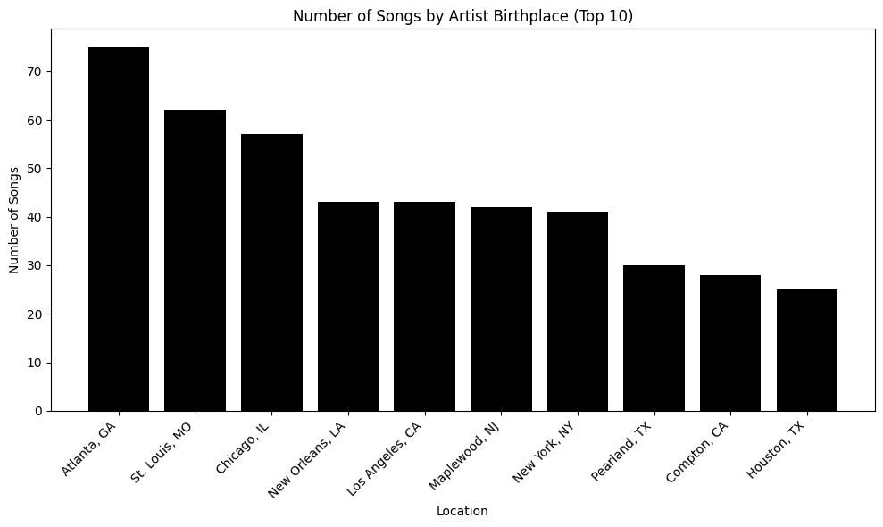

```python
# Count the number of observations grouped by 'location'
top_10_locations = tracks.groupby('location').size().reset_index(name='count')

# Sort the locations by count in descending order
top_10_locations = top_10_locations.sort_values(by='count', ascending=False)

# Display the top 10 locations
top_10_locations = top_10_locations.head(10)

# Plot the top 10 counts with black bars
plt.figure(figsize=(10, 6))
plt.bar(top_10_locations['location'], top_10_locations['count'], color='black')  # Change color to black
plt.xlabel('Location')
plt.ylabel('Number of Songs')
plt.title('Number of Songs by Artist Birthplace (Top 10)')
plt.xticks(rotation=45, ha='right')
plt.tight_layout()

plt.show()
```

### Heatmaps

Next, I created a heatmap of songs in my library. When users log into the web application, they will be greeted with a captivating heatmap visualization that offers a unique perspective on their music library. This heatmap provides an aggregate overview, showcasing the geographic origins of the artists behind their favorite songs. As users explore the heatmap, they'll gain insights into the diverse regional influences shaping the music they love.

```python
from geopy.geocoders import Nominatim, GoogleV3
```

```python
# Geocoding Locations
tracks_df = tracks

## Initialize Nominatim geocoder
geolocator = Nominatim(user_agent="myGeocoder")

## Initialize Google geocoder (requires API key)
google_api_key = 'AIzaSyAWWuglVrkcLzlf2k_V_1wjnl2rt9J27Is'  # Replace with your Google API key
geolocator = GoogleV3(api_key=google_api_key)

## Function to geocode locations
def geocode_location(location):
    try:
        geo_location = geolocator.geocode(location)
        if geo_location:
            return Point(geo_location.longitude, geo_location.latitude)
        else:
            return None
    except Exception as e:
        print(f"Error geocoding {location}: {e}")
        return None

## Geocode locations in the 'location' column
tracks_df['geometry'] = tracks_df['location'].apply(geocode_location)

## Convert DataFrame to GeoDataFrame
tracks_gdf = gpd.GeoDataFrame(tracks_df, geometry='geometry')
```

```python
# Create a base map centered at a specific location with dark style
m = folium.Map(location=[40.7128, -74.0060], zoom_start=4, tiles='CartoDB dark_matter')

# Drop rows with None values in the 'geometry' column
tracks_gdf = tracks_gdf.dropna(subset=['geometry'])

# Create HeatMap layer using the points in the 'geometry' column
heat_data = [[point.y, point.x] for point in tracks_gdf['geometry']]

# Define custom gradient
gradient = {0.4: '#4C17CD', 0.65: '#F71362', 1: '#FF8D44'}

HeatMap(heat_data, gradient=gradient).add_to(m)
# Display the map directly in Jupyter Notebook
m
```

Make this Notebook Trusted to load map: File -> Trust Notebook

[interactive chart not shown]

### Genre Exploration

Next, I filter my data for songs categorized as drill. This map depicts hotspots in Chicago, Miami, New York, and the United Kingdom. Thinking back on the history of drill music, this change in the map tells the story of a genre started in Chicago, reincarnated in the UK, and readapted in Brooklyn, NY.

```python
# Filter tracks data where 'genre' contains 'drill'
filtered_gdf = tracks_gdf[tracks_gdf['genre'].str.contains('drill', case=False, na=False)]

# Create a base map centered at a specific location with dark style
m_filtered = folium.Map(location=[40.7128, -74.0060], zoom_start=4, tiles='CartoDB dark_matter')

# Create HeatMap layer using the filtered points in the 'geometry' column
heat_data_filtered = [[point.y, point.x] for point in filtered_gdf['geometry']]

# Define custom gradient
gradient = {0.4: '#4C17CD', 0.65: '#F71362', 1: '#FF8D44'}

HeatMap(heat_data_filtered, gradient=gradient).add_to(m_filtered)

# Display the filtered map directly in Jupyter Notebook
m_filtered
```

Make this Notebook Trusted to load map: File -> Trust Notebook

[interactive chart not shown]

## Conclusion

I aim for users to gain deeper insights into the regional influences shaping music through these maps. By exploring the geographical distribution of artists, users can uncover the rich history and socioeconomic factors that have contributed to the creation of the music they cherish. This exploration aims to spark curiosity and foster a greater understanding of the cultural landscapes underlying their favorite music genres.

## References

Harper, G. (2016, January 8). Nashville music industry: Impact, contribution and Cluster Analysis: MC2. RIAA. https://www.riaa.com/reports/nashville-music-industry-impact-contribution-and-cluster-analysis/

Hodgson, J. (2023, July 25). The secret history of drill. VICE. https://www.vice.com/en/article/4a3x3m/secret-history-drill-music

Shelowitz, J., & Ismail, A. (2019). The rap quotes coast to coast a photographic catalog and maps of site-specific rap lyrics in New York, Los Angeles, Philadelphia, Atlanta, Houston and more. Dokument Press.

Turnbull, D. (n.d.). Find Your Favorite Local Artists and Events. Localify. https://localify.org/